# Practical Machine Learning Coursera Project

Jonny Uribe

March 19, 2015

This is a brief document describing the project assignment solution given in the coursera course Practical Machine Learning. The complete R code can be accesed in **CODE**: http://sirjoy.github.io/p3.html.

For the solution I tried initially to employ the same characteristics that the authors of the database used and that were described in the publication: **Qualitative Activity Recognition of Weight Lifting Exercises** available in http://groupware.les.inf.puc-rio.br/work.jsf?p1=11201. Unfortunately not all the 17 best described characteristis were ready available in the downladed database.

In fact we found that many characteristics were actually plague with many NA:

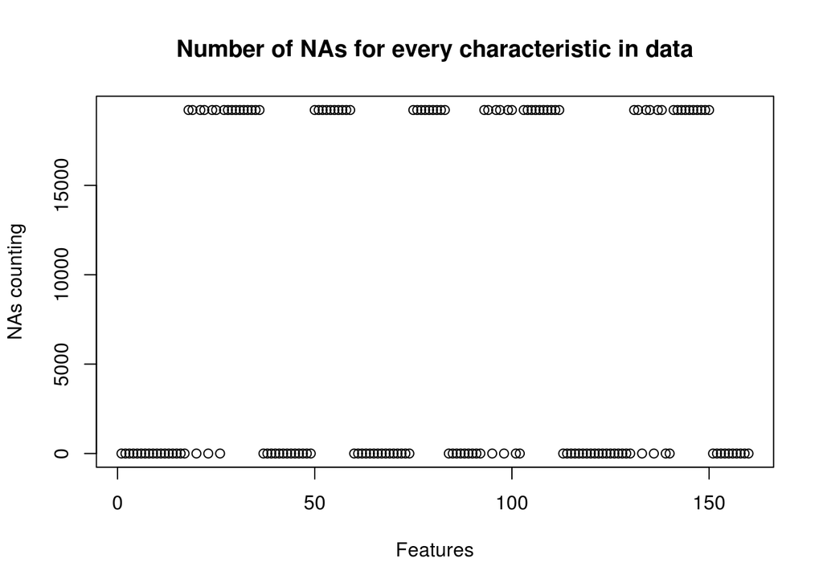

So we decided to use only the characteristics without NAs and those that were numeric.

We use the training original data for creating a partition with **80%** of samples for actually **training** the model and **20% for testing** internally the model performance. This was done with the intention of estimating in better way the error of the system.

A **PCA** representation of data was used selecting components with 80% of variance. 13 new features emerged.

For the classification model a **random forest** was used trained with 10 fold cross validation. Parameter mtyr of 2 was the best, it mean randonly selecting 2 features on every tree node.

On the test partition accuracy was **0.89**. So we were expecting the system will fail around 1 time every 10 uses. On the test files submitted individually we got only one fail (in sample 11) so the system was better than expected.